# A Brief Analysis of Speed Dating

Group 003: Tim Brown, Hannah Striebel, Derien Weatherspoon

22 April 2021

# Introduction

Over the course of this project, we hope to gain insight into how people view potential significant others through the use of a speed dating dataset collected from students at Columbia University. This dataset consists of 276 “dates,” where a male and female pair had a four minute speed date and then filled out a form rating various attributes about their date from 1 to 10. The dataset also includes information about each partner, such as their age, race, and gender.

```
Rows: 276
Columns: 22
$ DecisionM        <int> 0, 1, 1, 1, 1, 0, 0, 0, 1, 0, 0, 0, 0, 0, 1, 1, 1,...
$ DecisionF        <int> 0, 0, 0, 1, 1, 0, 1, 0, 1, 0, 1, 0, 0, 0, 1, 1, 0,...
$ LikeM            <dbl> 6, 8, 10, 9, 7, 6, 2, 7, 8, 5, 3, 7, 8, 4, 6, 7, 8...
$ LikeF            <dbl> 7, 7, 6, 7, 5, 6, 6, 6, 7, 8, 7, 8, 8, 3, 6, 7, 8,...
$ PartnerYesM      <int> 5, 4, 10, 7, 8, 6, 1, 7, 8, 5, 1, NA, 5, 1, 5, 7, ...
$ PartnerYesF      <int> 5, 3, 2, 8, 5, 1, 5, 6, 10, 7, 7, 5, 1, 2, 6, 5, 5...
$ AgeM             <int> 27, 22, 22, 23, 24, 25, 30, 27, 28, 24, 25, 30, 23...
$ AgeF             <int> 21, 22, 23, 24, 26, 26, 21, 23, 25, 25, 25, 23, 23...
$ RaceM            <fct> Caucasian, Caucasian, Asian, Caucasian, Latino, Ca...
$ RaceF            <fct> Caucasian, Asian, Asian, Caucasian, Other, Caucasi...
$ AttractiveM      <dbl> 6, 7, 10, 9, 7, NA, 3, 6, 8, 5, 5, 10, 6, 4, 6, 7,...
$ AttractiveF      <dbl> 5, 6, 4, 7, 5, 5, 7, 5, 8, 8, 6, 8, 8, 4, 6, 6, 8,...
$ SincereM         <int> 8, 9, 10, 9, 9, 8, 6, 7, 7, 6, 6, 10, 10, 6, 7, 8,...
$ SincereF         <int> 8, 6, 7, 9, 10, 10, 6, 9, 8, 7, 8, 9, 8, 7, 8, 7, ...
$ IntelligentM     <dbl> 8, 10, 10, 9, 8, 7, 7, 8, 8, 8, 6, 10, 9, 7, 6, 7,...
$ IntelligentF     <int> 8, 8, 9, 7, 8, 6, 7, 9, 5, 9, 9, 8, 10, 8, 8, 7, 8...
$ FunM             <int> 8, 6, 10, 9, 9, 7, 5, 6, 10, 5, 5, 10, 8, 3, 6, 6,...
$ FunF             <int> 2, 4, 4, 6, 8, 4, 4, 5, 9, 7, 7, 5, 7, 2, 7, 6, NA...
$ AmbitiousM       <int> 7, 6, 10, 9, 7, 7, 8, 6, 8, 8, 7, 10, 10, 6, 8, 6,...
$ AmbitiousF       <int> 2, 9, 3, 5, 5, 6, 6, 9, 8, 9, 7, 9, 7, 6, 7, 7, 8,...
$ SharedInterestsM <dbl> 6, 5, 10, 9, 7, 7, 7, 5, 10, 6, 3, NA, NA, 4, 5, 6...
$ SharedInterestsF <dbl> 2, 4, 2, 7, 5, NA, 7, 7, 9, 7, 8, 5, 7, 2, 6, 5, 7...
```

By leveraging the information in this dataset, we hope to find answers to a number of questions pertaining to dating. Do people prefer to date inside or outside their own ethnicity? Are males or females more likely to want a second date? Do females tend to rate males higher than males rate females? In what categories? Which features (attractiveness, sincerity, intelligence, etc) are most predictive of wanting a second date? Does this differ by gender? Age? Race?

By answering these questions, we hope to gain quantitative insight and understanding into the complex human experience of dating.

# Methods

To analyze the potential differences between the genders, very simple measures can be taken. Each factor is already separated by gender so the comparison for any individual factor, such as Fun or Sincerity, can be made by directly comparing the distribution of numerical ratings on a histogram, as well as comparing the averages of those distributions. To visualize some of the surface-level disparities directly related to race, filtering can be used to sort each group on whether or not the race of their partner matched their own race.

To determine which features are most predictive of wanting a second date, the ratings of features will be plotted, separated by whether or not the individual wanted a second date. If the distribution of ratings for a given feature for both “yes” and “no” are similar, then that feature is not predictive of wanting a second date. However, if the distribution of ratings for “yes” is significantly higher or lower than that of “no”, this indicates that this feature is predictive of wanting a second date. Multiple Linear Regression can also be used to attempt to determine which variables are most predictive.

# Results

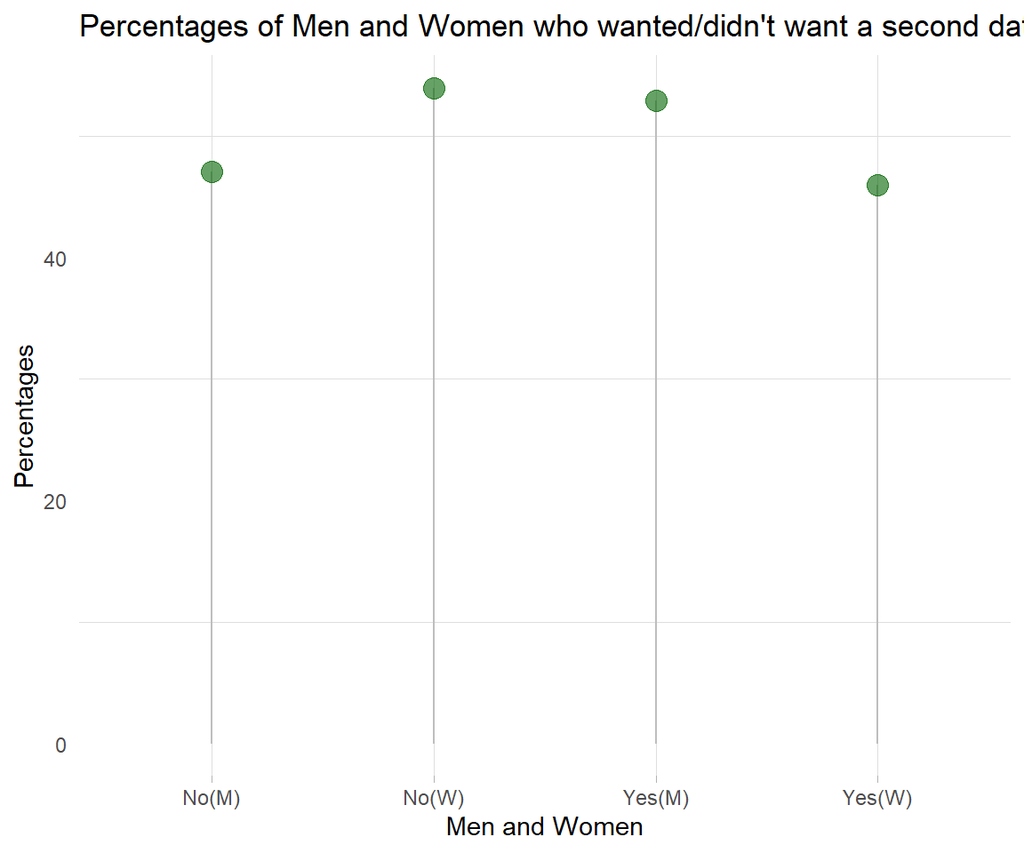

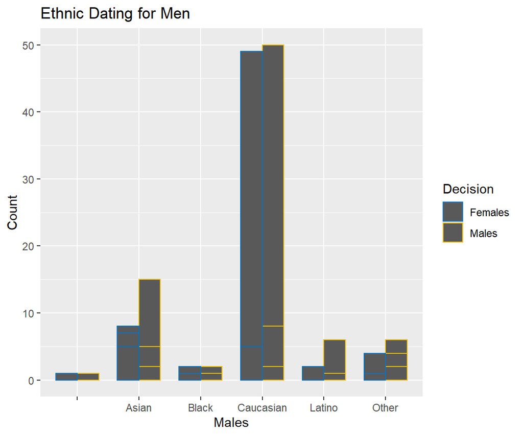

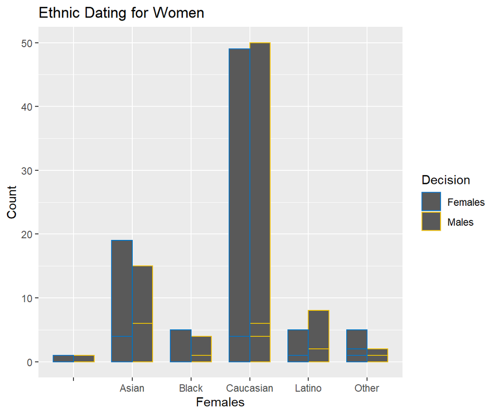

The distribution of ethnicity dating decisions are for the most part, evenly spread out throughout the sample of men and women.

Most category ratings displayed relative parity between the two sexes, though some distinctions arose upon further analysis. Men, on average, rated women’s Shared Interests higher than women rated men’s. In both the Sincerity and Fun categories, women also rated men on a more even distribution than their male counterparts who clustered their ratings more densely around 6,7 and 8; though this was very subtle. When race became a factor and the two sexes were separated into two groups for analysis, Same Race and Different Race. The distribution for ratings given by women nearly didn’t change at all. However, there was a subtle drop in attractiveness ratings given by men when their partner was not of the same race as they were.

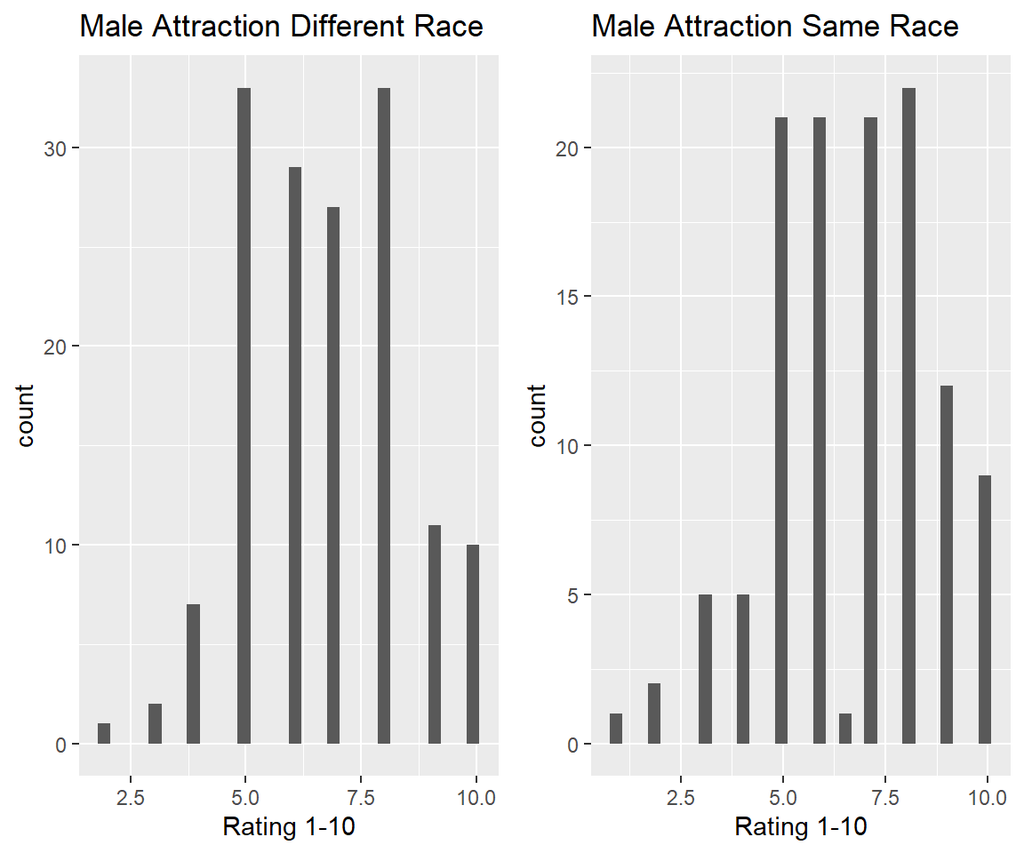

Though given the sample size, this may be due to a few outliers as it is a subtle shift in the distribution yet the means are similar.

Which features are most predictive of wanting a second date? Does this differ by gender? Age? Race?

As you can see from the box-plots below, the feature for which the “Yes” and “No” distribution are most dissimilar, and thus most predictive of wanting a second date is `Attractive`. In addition, `Fun` and `Shared Interests` also show a gap between “Yes” and “No.”

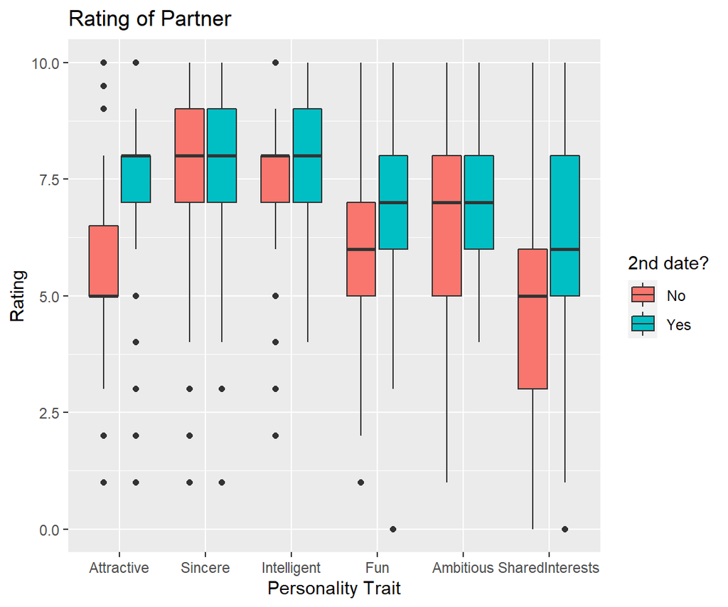

By creating a linear model using all the features and then deriving the most parsimonious model, we can analytically determine which features are most predictive.

| term | estimate | std.error | statistic | p.value |
| --- | --- | --- | --- | --- |
| (Intercept) | -0.42263007 | 0.07524805 | -5.616492 | 3.366208e-08 |
| Attractive | 0.10397260 | 0.01211845 | 8.579692 | 1.446675e-16 |
| SharedInterests | 0.04457481 | 0.01037658 | 4.295714 | 2.123213e-05 |

| r.squared | adj.r.squared |
| --- | --- |
| 0.2576666 | 0.25446 |

The results from the linear model align with what we previously discovered from the box plots - `Attractive` and `Shared Interests` are the most predictive features of wanting a second date. However, it is worth noting that this only results in an r-squared value of about .25, which means that only a quarter of the variation in the data is accounted for by our linear model. This is most likely due to the fact that each person in the study has individual tastes, and that even though `Attractive` and `Shared Interests` are the most predictive *on average*, some people may value other traits more.

# Conclusion

The dataset is from Columbia University, which is a reliable source. The dataset is valid for evaluating interpolated results, but may not extrapolate well. In addition, From the description of the data, the only participants were college students. This could bias our findings and potentially render them inaccurate when applied to the general populace. This study also focusses solely on heterosexual speed dates and further narrows the group that the findings could shed light on. Due to the study focusing on speed dating, which are dates around 4-5 minutes, the data could show bias against people who need more than that time given to give ratings on someone. Furthermore, due to the relatively small sample size of the data, outliers are bound to have a much more pronounced effect on the overall findings in certain test cases. While the methods used throughout the analysis are statistically sound, there was not a concerted effort to clean the data/cull obvious outliers from the dataset before analysis.

In the future, we could improve our analysis through a number of means. Instead of merely graphing, we could perform hypothesis tests to see if differences in groups (gender, for example) were statistically significant from one another. Further analysis could be done using predictions instead of simply visualizing the data and interpreting it. In addition, there are a whole host of questions that could be further explored with this data. Given the time that has elapsed since the dataset was collected, we could also delve into the potential shifts in these categories by examining current college students alongside the general population of today. With this more recent repetition we would be able to observe and document any potential changes in preferences, priorities, desirable traits, as well as open the study up to be both more inclusive and comprehensive.

# Sources

Gelman, A. and Hill, J., *Data analysis using regression and multi-level/hierarchical models*, Cambridge University Press: New York, 2007.

Müller, K., & Wickham, H. (n.d.). *Group by one or more variables* — group_by. Https://Dplyr.Tidyverse.Org. Retrieved April 22, 2021, from https://dplyr.tidyverse.org/reference/group_by.html

Wickham, H., Chang, W., Henry, L., Pedersen, T., Takahashi, K., Wilke, C., … Dunnington, D. (n.d.). *Function reference*. ggplot2 Reference. https://ggplot2.tidyverse.org/reference/.